# Healthcare analysis

CUNHA, LUIS

December 12, 2018

# **Problem 1**

- Use the dataset healthcare data frame (see below) to fit
  - an OLSR linear (lm) model
  - a CART (rpart) model
- to predict **costs**
- Explore the dataset as needed to guide your analysis
- Prepare your dataset (e.g., to avoid overfitting)
- Fit your models using lm and rpart
- Tune your models to optimize performance
- Show and *explain* your results, use plots where appropriate
- Evaluate model performance
- State your conclusions

Use **only** OLSR (lm) and CART (rpart) models; do not use caret in Problem 1

```r
#  Do not change the code in this chunk!
healthcare <- read_csv('healthcare.csv')
```

## Understand healthcare dataset

In this section I will analyse the structure of dataset, in order to:

- Understand variables’ values, distinct values, min, max, means
- Identify units for each variable to better interpret data
- Identify Categorical vs Numerical variables
- Find and remove incomplete cases in the dataset (NAs)

### Analyze dataset for numerical vs categorical variables and distinct values

```r
# First dataset look
head(healthcare)
```

```
# A tibble: 6 x 8
  age_yrs gender body_mass no_children smoker region    prev_balance  costs
    <int> <chr>      <dbl>       <int> <chr>  <chr>            <dbl>  <dbl>
1      18 female      42.2           0 yes    southeast      -17938. 38793.
2      43 female      30.7           2 no     northwest         195.  8311.
3      62 male        37.4           0 no     southwest       -4273. 12979.
4      49 female      23.2           2 no     northwest        1480. 10157.
5      46 male        40.4           2 no     northwest        -671.  8733.
6      63 male        36.8           0 no     northeast        5672. 13982.
```

Since we have Categorical variables in the dataset, we will first transform them to factors.

```r
# Changing discrete variables to factors to enable plotting using pairs()
healthcare <- healthcare %>%
  mutate(gender = as.factor(gender),
         smoker = as.factor(smoker),
         region = as.factor(region))
```

Let’s analyse how data looks like

```r
# Identifying datatypes, min, max and mean
summary(healthcare)
```

```
    age_yrs         gender      body_mass      no_children    smoker
 Min.   :18.00   female:662   Min.   :15.96   Min.   :0.000   no :1064
 1st Qu.:27.00   male  :676   1st Qu.:26.30   1st Qu.:0.000   yes: 274
 Median :39.00                Median :30.40   Median :1.000
 Mean   :39.21                Mean   :30.66   Mean   :1.095
 3rd Qu.:51.00                3rd Qu.:34.69   3rd Qu.:2.000
 Max.   :64.00                Max.   :53.13   Max.   :5.000
       region     prev_balance           costs
 northeast:324   Min.   :-27607.54   Min.   : 1122
 northwest:325   1st Qu.: -1340.00   1st Qu.: 4740
 southeast:364   Median :   -13.35   Median : 9382
 southwest:325   Mean   :   136.09   Mean   :13270
                 3rd Qu.:  1427.87   3rd Qu.:16640
                 Max.   : 30313.76   Max.   :63770
```

**Healthcare dataset analysis conclusion**

3 categorical variables:

- gender - Person’s gender: female or male
- smoker - Person smokes: yes or no
- region - Person’s region: southeast, southwest, northeast, northwest

#### Check for missing data

Let’t check if we have any incomplete observations that could impact our predicting models (NAs present in dataset cells):

```r
# Look for any rows with missing data on its columns
nrow(healthcare[!complete.cases(healthcare),])
```

```
[1] 0
```

There is no data returned by the instruction above, all our observations have complete information, all columns are filled with a concrete value.

In the next section we will analyse our data deeper, to get some intuition about it.

## Exploratory data analysis

Understanding existent relationships in the dataset is key for a good interpretation of results. Goal is to create some intuition about our data using a visual aproach; the assumptions made during this first approach, will be validated by our model, assessing predictors’ influence.

The following plot show us the relationship between variables.

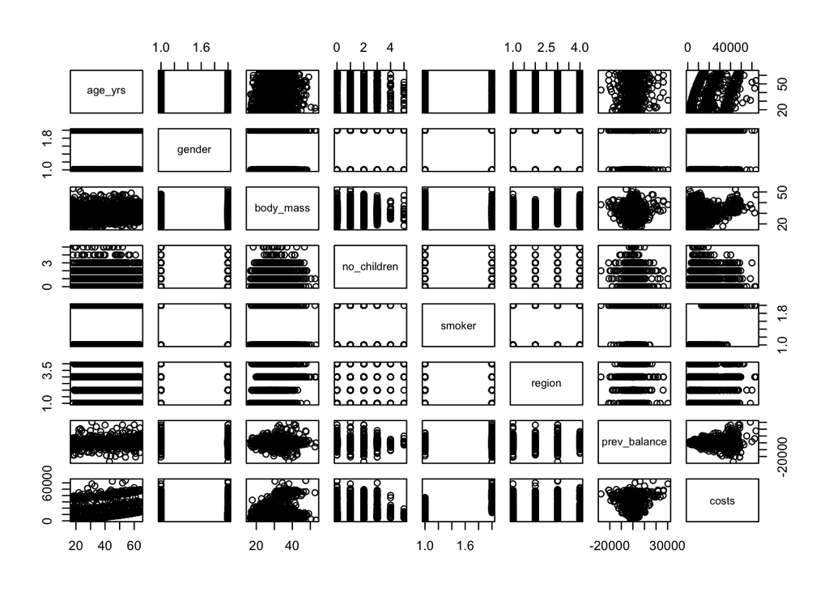

```r
# Plotting all pairs to understand relationships between each variable.
pairs(healthcare)
```

From the chart above we can already see some potential relations, between costs and:

- age_yrs
- body_mass
- smoker

Let’s confirm and explore those relations in the next section.

### Can we identify any stronger relations with Costs?

In these section we will zooming-in into the potential correlations identified in the previous chart. We will do that by analysing Costs by different variables.

**Costs seems to have a strong correlation with:**

- **Age**, it suggests a strong positive correlation, indicates that costs increase with age. However, it seems that there are 3 distinct groups, let’s see if we can identify them by any other variable.

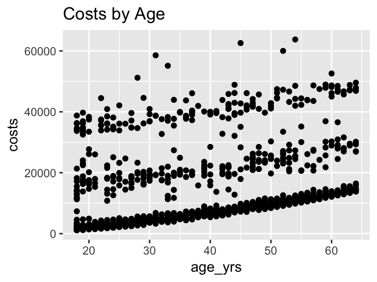

```r
# Using scatterplot to map costs by age_yrs
ggplot(healthcare, aes(x=age_yrs, y=costs)) +
  geom_point() +
  ggtitle("Costs by Age")
```

- **Smoker and Age**, there is a relation with smokers, age and costs; from the chart below, seems that a smoker has higher costs that a non-smoker, but by how much?

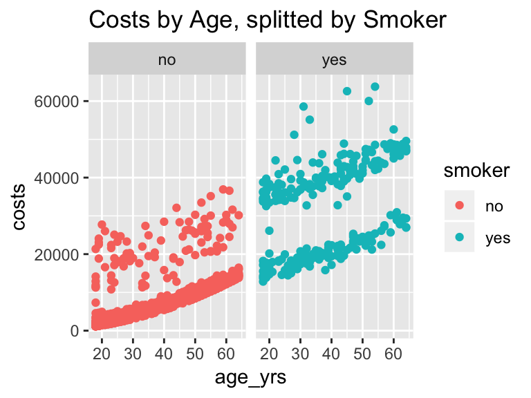

```r
# Using scatterplot to map costs by age_yrs, splitted by smoker
ggplot(healthcare, aes(x=age_yrs, y=costs, col=smoker)) +
  geom_point() +
  facet_grid(.~ smoker) +
  ggtitle("Costs by Age, splitted by Smoker")
```

It seems that the costs for a person that smokes are around $20,000 higher than a person that doesn’t smoke, across all ages. Let’s confirm this assumption by fitting a linear model on costs as a function of age and smoker variables:

```r
# Follow model demonstrates the costs difference between smokers and non-smokers
costs_smoker_model <- lm(costs ~ age_yrs + smoker, data= healthcare)

# Print summary of fitted model
summary(costs_smoker_model)
```

```
Call:
lm(formula = costs ~ age_yrs + smoker, data = healthcare)

Residuals:
     Min       1Q   Median       3Q      Max
-16088.1  -2046.8  -1336.4   -212.7  28760.0

Coefficients:
            Estimate Std. Error t value Pr(>|t|)
(Intercept) -2391.63     528.30  -4.527 6.52e-06 ***
age_yrs       274.87      12.46  22.069  < 2e-16 ***
smokeryes   23855.30     433.49  55.031  < 2e-16 ***
---
Signif. codes:  0 '***' 0.001 '**' 0.01 '*' 0.05 '.' 0.1 ' ' 1

Residual standard error: 6397 on 1335 degrees of freedom
Multiple R-squared:  0.7214,    Adjusted R-squared:  0.721
F-statistic:  1728 on 2 and 1335 DF,  p-value: < 2.2e-16
```

Yes! It seems that in average, a person that smokes has a cost of $23,855.30 more than a person that doesn’t. Also, if we take age_yrs into account, for each “year old” a person has, the cost raises $274.87.

This result provides us a confidence rate higher than 95% for the p-value of both predictors, telling us that they are relevant to explain Costs.

- **Smoker and Gender**, pretty evident is the increase of costs within smokers. Let’s see if the same behavior is dependent on gender:

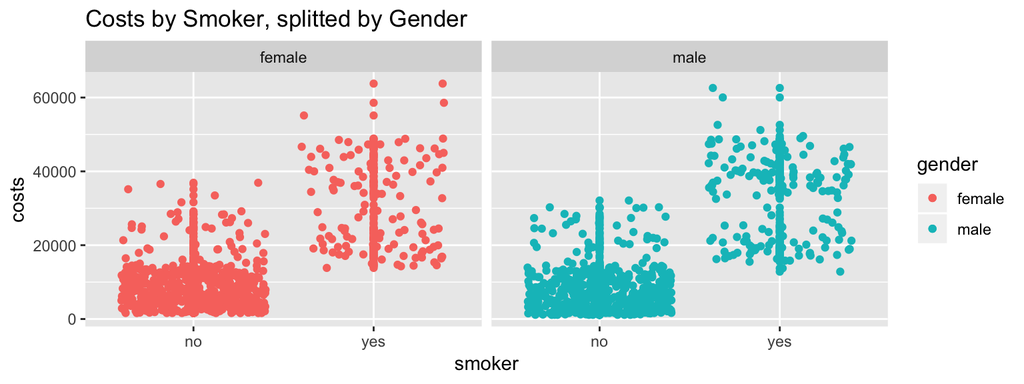

```r
# Using scatterplot to understand relaiton between costs, gender, per smoke class
ggplot(healthcare, aes(x=smoker, y=costs, col=gender)) +
  geom_point() +
  facet_grid(.~gender) +
  geom_jitter() +
  ggtitle("Costs by Smoker, splitted by Gender")
```

Doesn’t seem that Gender provides more information to the model, this variable has consistent behavior between its values.

- **Previous Balance**, from the chart below we realize that there is an increase on costs for people with previous balances outside [-5000, 5000] range. Can this behavior be related with the fact that smokers have a higher cost?

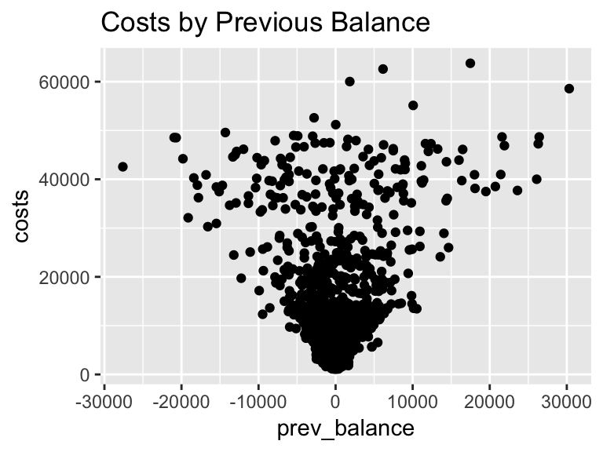

```r
# Using scatterplot to understand relaiton between costs, gender, per smoke class
ggplot(healthcare, aes(x=prev_balance, y=costs)) +
  geom_point() +
  ggtitle("Costs by Previous Balance")
```

- **Smoker and Previous Balance**, the chart below shows that non smokers tend to have a less sparse previous balance:

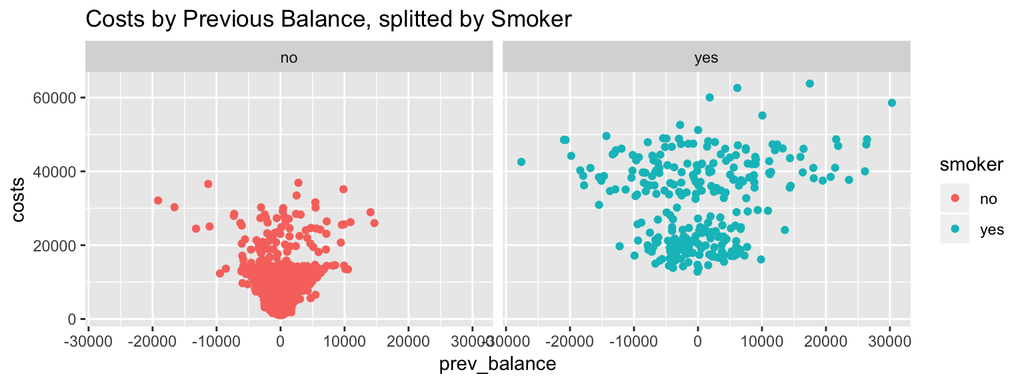

```r
# Using scatterplot to understand relaiton between costs, gender, per smoke class
ggplot(healthcare, aes(x=prev_balance, y=costs, col=smoker)) +
  geom_point() +
  facet_grid(.~smoker) +
  ggtitle("Costs by Previous Balance, splitted by Smoker")
```

Indeed, the smokers grop tend to have more sparse previous balances and a increase costs.

- **Body Mass and Smoker**, it seems that we have a strong correlation between costs, smokers and body mass.

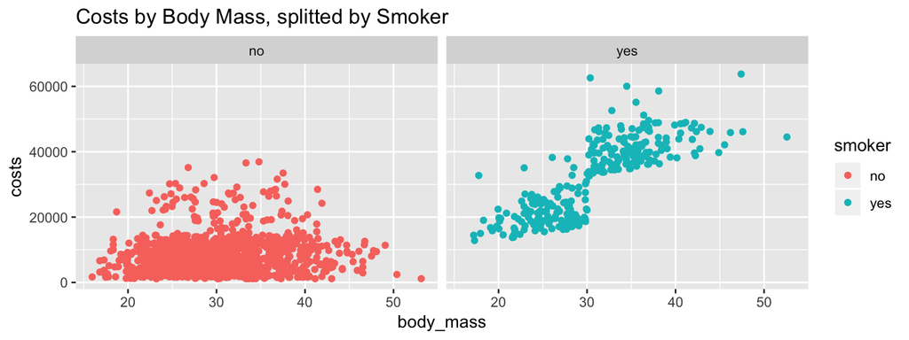

```r
# Using scatterplot to map costs by body_mass and coloring by previous balance
ggplot(healthcare, aes(x=body_mass, y=costs, col=smoker)) +
  geom_point() +
  facet_grid(.~smoker) +
  ggtitle("Costs by Body Mass, splitted by Smoker")
```

From the chart above, we can infer that people that smoke have a baseline health cost higher than people that don’t.

On top of that something is very clear, people that smoke and have a BMI > 30 has, in average, costs increase fromm $30.000 up to $60.000.

In contrast, people of same age that don’t smoke, in average they stick below the $20.000 threshold!

Now that we have a better perspective on the dataset and understand some of the clear relations in the data, it’s time to fit our models. Let’s first split our data in 2, this will help us to train and test our model against never seen data. It’s good to understand how well our model performs, in other words, if it generalizes well!

## Split our dataset into Train and Test buckets

In this section, healthcare will be splitted in 2 subsets. The Train subset will contain 80% of the entire population, it will be used to train our prediction models. To assess models’ performance, the Test subset will be used.

This method will avoid model overfitting, providing us a Test set to asssess models performance.

```r
set.seed(1)
# Create the indexes for Train and Test samples
health_indexes <- sample(1:2, size = nrow(healthcare), prob = c(0.8,0.2), replace = TRUE)

# Create a train and tests from healtchare data frame
healthcare_train <- healthcare[health_indexes == 1, ] # subset healthcare to training indices only
healthcare_test <- healthcare[health_indexes == 2, ] # subset healthcare to validation indices only
```

- healthcare_train - it will be used to train our models, we used 80% of entire population to do that
- healthcare_test - will be used to test our models, check how well it generalizes

## Fit regression models

### Using a OLSR - Linear model - lm()

Applying a linear regression model to healthcare dataset, we are going to fit a model for Costs using all variables in our dataset, we want to assess the quality of the model and also validate our conclusions performed in the earlier section: Exploratory Data Analysis.

```r
set.seed(1)
# Apply a linear model to fit costs with all other features on our datset
healthcare_lm <- lm(costs ~ ., data=healthcare_train)

# Summary of the model
summary(healthcare_lm)
```

```
Call:
lm(formula = costs ~ ., data = healthcare_train)

Residuals:
   Min     1Q Median     3Q    Max
-11426  -2956   -961   1552  29460

Coefficients:
                  Estimate Std. Error t value Pr(>|t|)
(Intercept)     -1.247e+04  1.108e+03 -11.257  < 2e-16 ***
age_yrs          2.523e+02  1.344e+01  18.767  < 2e-16 ***
gendermale      -1.695e+01  3.756e+02  -0.045  0.96401
body_mass        3.591e+02  3.253e+01  11.037  < 2e-16 ***
no_children      4.935e+02  1.551e+02   3.182  0.00151 **
smokeryes        2.384e+04  4.620e+02  51.607  < 2e-16 ***
regionnorthwest -3.414e+02  5.345e+02  -0.639  0.52305
regionsoutheast -8.954e+02  5.455e+02  -1.641  0.10099
regionsouthwest -8.950e+02  5.349e+02  -1.673  0.09459 .
prev_balance     6.846e-02  3.953e-02   1.732  0.08359 .
---
Signif. codes:  0 '***' 0.001 '**' 0.01 '*' 0.05 '.' 0.1 ' ' 1

Residual standard error: 6120 on 1067 degrees of freedom
Multiple R-squared:  0.7532,    Adjusted R-squared:  0.7511
F-statistic: 361.8 on 9 and 1067 DF,  p-value: < 2.2e-16
```

From the result of the Linear regression model, we conclude that there are predictors that don’t impact the quality of our model - Gender, Region - maybe because they are “embedded”" in other, more explanatory, varaibles. All other predictors are relevant for the model; furthermore, looking into p-values, we can now validate our assumptions from previous section (Exploratory data analysis), by descending order of importance:

- **smoker** - based on t value, this is the variable that describes our costs better, we now have proved that our analysis was correct
- **age_yrs** - very important, as costs grows with age
- **body_mass** - also important, since a higher body_mass implies more health costs
- **no_children** - this variable also has some importance but its t-value and p-value are smaller than all other relevant variables

Also our adjusted R-squared tell us that 75% of variance in Costs has been explained by the model. It’s not great but let’s see if we can maintain the same result decreasing the complexity of the model. This information will be used to tune our model.

Before tuning the model, we will assess how well it generalizes with our Test subset.

#### Asssess RMSE and $R^{2}$ on our Test dataset

Below we will make predictions with new data, never seen by the model, it will help us to understand how good it is.

```r
set.seed(1)
predictions_lm <- predict(healthcare_lm, healthcare_test)

# Calculate RMSE manually for our Test set
rmse_lm <- sqrt(mean((healthcare_test$costs-predictions_lm)^2))

sprintf("Our RMSE is %.0f, it means that average error of our model for a new observation is: %0f",rmse_lm, rmse_lm)
```

```
[1] "Our RMSE is 5788, it means that average error of our model for a new observation is: 5787.527488"
```

```r
# Calculate R^2 for our Test set
SSres_lm <- sum((healthcare_test$costs - predictions_lm)^2)
SStot_lm <- sum((healthcare_test$costs - mean(healthcare_test$costs))^2)

r2_lm <- 1- (SSres_lm / SStot_lm)

sprintf("Our R^2 is: %.0f%%, it means that our model explains %.0f%% of the result variance. Let's see if tuning the model we can maintain the same R^2 and RMSE.",r2_lm*100,r2_lm*100)
```

```
[1] "Our R^2 is: 74%, it means that our model explains 74% of the result variance. Let's see if tuning the model we can maintain the same R^2 and RMSE."
```

#### Tuning our Linear model

Let’s look into our t and p values again and adjust the model based on that information, removing any non statistical significant to the final result.

```r
# Linear regression output
summary(healthcare_lm)
```

```
Call:
lm(formula = costs ~ ., data = healthcare_train)

Residuals:
   Min     1Q Median     3Q    Max
-11426  -2956   -961   1552  29460

Coefficients:
                  Estimate Std. Error t value Pr(>|t|)
(Intercept)     -1.247e+04  1.108e+03 -11.257  < 2e-16 ***
age_yrs          2.523e+02  1.344e+01  18.767  < 2e-16 ***
gendermale      -1.695e+01  3.756e+02  -0.045  0.96401
body_mass        3.591e+02  3.253e+01  11.037  < 2e-16 ***
no_children      4.935e+02  1.551e+02   3.182  0.00151 **
smokeryes        2.384e+04  4.620e+02  51.607  < 2e-16 ***
regionnorthwest -3.414e+02  5.345e+02  -0.639  0.52305
regionsoutheast -8.954e+02  5.455e+02  -1.641  0.10099
regionsouthwest -8.950e+02  5.349e+02  -1.673  0.09459 .
prev_balance     6.846e-02  3.953e-02   1.732  0.08359 .
---
Signif. codes:  0 '***' 0.001 '**' 0.01 '*' 0.05 '.' 0.1 ' ' 1

Residual standard error: 6120 on 1067 degrees of freedom
Multiple R-squared:  0.7532,    Adjusted R-squared:  0.7511
F-statistic: 361.8 on 9 and 1067 DF,  p-value: < 2.2e-16
```

Based on our conclusions, we can remove gender and region from the model, let’s give it a try and assess performance:

```r
set.seed(1)
# Apply a linear model to fit costs with a subset of feaures
healthcare_lm_1 <- lm(costs ~ age_yrs + smoker + body_mass +  no_children , data=healthcare_train)

# Looking into our new model
summary(healthcare_lm_1)
```

```
Call:
lm(formula = costs ~ age_yrs + smoker + body_mass + no_children,
    data = healthcare_train)

Residuals:
     Min       1Q   Median       3Q      Max
-11517.3  -3027.1   -923.6   1593.4  29469.7

Coefficients:
             Estimate Std. Error t value Pr(>|t|)
(Intercept) -12677.43    1056.09 -12.004   <2e-16 ***
age_yrs        254.31      13.42  18.950   <2e-16 ***
smokeryes    23867.90     460.08  51.878   <2e-16 ***
body_mass      345.48      31.01  11.140   <2e-16 ***
no_children    493.46     155.03   3.183   0.0015 **
---
Signif. codes:  0 '***' 0.001 '**' 0.01 '*' 0.05 '.' 0.1 ' ' 1

Residual standard error: 6125 on 1072 degrees of freedom
Multiple R-squared:  0.7516,    Adjusted R-squared:  0.7507
F-statistic: 810.9 on 4 and 1072 DF,  p-value: < 2.2e-16
```

This gives us a good understanding of to-dos and not to-dos in real life!

The tuned model maintains the Adjusted R-squared in the training model, this is a good sign; however, we need to assess the performance on our Test dataset:

```r
set.seed(1)
# Calculate predictions based on new model
predictions_lm_1 <- predict(healthcare_lm_1, healthcare_test)

# Calculate RMSE manually for our Test set
rmse_lm_1 <- sqrt(mean((healthcare_test$costs-predictions_lm_1)^2))

sprintf("Our RMSE is %.0f, it means that average error of our model for a new observation is: %0f",rmse_lm_1, rmse_lm_1)
```

```
[1] "Our RMSE is 5837, it means that average error of our model for a new observation is: 5836.648582"
```

```r
# Calculate R^2 for our Test set
SSres_lm_1 <- sum((healthcare_test$costs - predictions_lm_1)^2)
SStot_lm_1 <- sum((healthcare_test$costs - mean(healthcare_test$costs))^2)

r2_lm_1 <- 1- (SSres_lm_1 / SStot_lm_1)

sprintf("Our R^2 is: %.0f%%, it means that our model explains %.0f%% of the result variance. Let's see if tuning the model we can maintain the same R^2 and RMSE.",r2_lm_1*100,r2_lm_1*100)
```

```
[1] "Our R^2 is: 74%, it means that our model explains 74% of the result variance. Let's see if tuning the model we can maintain the same R^2 and RMSE."
```

Our model is now less complex (but quicker) with a subtil increase of RMSE and a decrease of $R^{2}$. We can say that generalizes well with less complexity!

Let’s have a try with a Regression Tree and assess its performance. Because we have several Categorical variables and some non-linear relations, could a Regression Tree model predict better than our Linear regression model?

### Using a CART - Regression Tree - rpart()

```r
set.seed(1)
# Fit a regression tree into Healthcare dataset
healthcare_dt <- rpart(formula = costs ~ .,
                       data = healthcare_train,
                       method = "anova")

# Textual representation of the tree fitted by the model
print(healthcare_dt)
```

```
n= 1077

node), split, n, deviance, yval
      * denotes terminal node

 1) root 1077 161912400000 13331.840
   2) smoker=no 853  30785210000  8378.314
     4) age_yrs< 44.5 507  11155310000  5533.499
       8) prev_balance>=-2987.364 493   8623338000  5188.477
        16) prev_balance< 2656.807 473   5995880000  4799.855 *
        17) prev_balance>=2656.807 20    866564300 14379.390 *
       9) prev_balance< -2987.364 14    406673500 17683.190 *
     5) age_yrs>=44.5 346   9514361000 12546.870 *
   3) smoker=yes 224  30492950000 32195.050
     6) body_mass< 30.01 108   3018665000 21642.470 *
     7) body_mass>=30.01 116   4250594000 42019.870 *
```

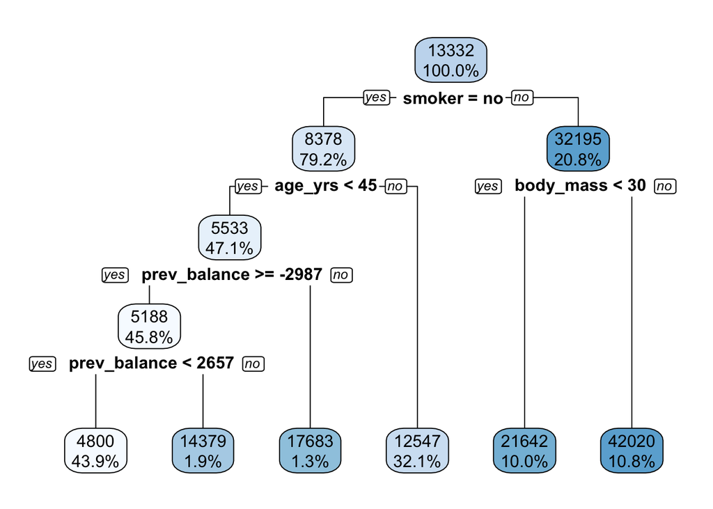

```r
# Graphical representation of the tree fitted by the model
rpart.plot(healthcare_dt, yesno = 2, digits=-3)
```

The output of the tree shows a more visual way to assess and predict the cost of new observations.

**Complexity Parameter and Splits**

Rpart already performed some pruning on the tree by assessing a range of cost of complexity(CP). The algorithm decided to use smoker, body_mass, age_yrs and prev_balance to predict the health cost.

The plot below shows CP values per number of splits.

```r
# Prints the Cross Validation relative error per CP
printcp(healthcare_dt)
```

```
Regression tree:
rpart(formula = costs ~ ., data = healthcare_train, method = "anova")

Variables actually used in tree construction:
[1] age_yrs      body_mass    prev_balance smoker

Root node error: 1.6191e+11/1077 = 150336515

n= 1077

        CP nsplit rel error  xerror     xstd
1 0.621535      0   1.00000 1.00207 0.057999
2 0.143434      1   0.37846 0.37919 0.021380
3 0.062475      2   0.23503 0.23898 0.016256
4 0.013126      3   0.17256 0.17874 0.014581
5 0.010876      4   0.15943 0.17354 0.014479
6 0.010000      5   0.14855 0.16381 0.013959
```

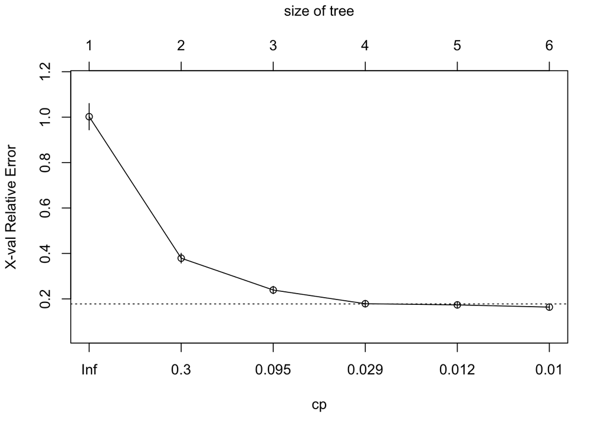

```r
plotcp(healthcare_dt)
```

Using the parameters that the algorithm chose, let’s assess performance:

```r
set.seed(1)
predictions_dt <- predict(healthcare_dt, healthcare_test)

# Calculate RMSE manually
rmse_dt <- sqrt(mean((healthcare_test$costs-predictions_dt)^2))

sprintf("Our RMSE is %.0f, it means that average error of our model for a new observation is: %0f",rmse_dt, rmse_dt)
```

```
[1] "Our RMSE is 4467, it means that average error of our model for a new observation is: 4467.439832"
```

```r
# Calculate R^2 for our Test set
SSres_dt <- sum((healthcare_test$costs - predictions_dt)^2)
SStot_dt <- sum((healthcare_test$costs - mean(healthcare_test$costs))^2)

r2_dt <- 1- (SSres_dt / SStot_dt)

sprintf("Our R^2 is: %.0f%%, it means that our model explains %.0f%% of the result variance. Let's see if tuning the model we can maintain the same R^2 and RMSE.",r2_dt*100,r2_dt*100)
```

```
[1] "Our R^2 is: 85%, it means that our model explains 85% of the result variance. Let's see if tuning the model we can maintain the same R^2 and RMSE."
```

Since both 5 and 6 splits are under our cross-validation error threshold of 0.2, let’s try to use 5 splits instead of 6.

**Optimal complexity parameter (CP) value that minimizes cross validation error**

```r
# Print the Complexity Parameter table and the xerrors
printcp(healthcare_dt)
```

```
Regression tree:
rpart(formula = costs ~ ., data = healthcare_train, method = "anova")

Variables actually used in tree construction:
[1] age_yrs      body_mass    prev_balance smoker

Root node error: 1.6191e+11/1077 = 150336515

n= 1077

        CP nsplit rel error  xerror     xstd
1 0.621535      0   1.00000 1.00207 0.057999
2 0.143434      1   0.37846 0.37919 0.021380
3 0.062475      2   0.23503 0.23898 0.016256
4 0.013126      3   0.17256 0.17874 0.014581
5 0.010876      4   0.15943 0.17354 0.014479
6 0.010000      5   0.14855 0.16381 0.013959
```

Model is already tuned to use a CP of 0.01, minimizing the cross validation error, creating 6 buckets; however, let’s try to increase the Complexity Parameter to 0.012 and assess RMSE and $R^{2}$ on the training test:

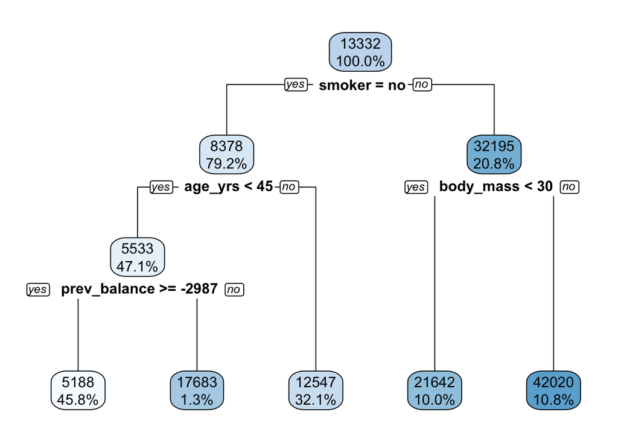

```r
set.seed(1)
# Pruning the model
healthcare_dt_1 <- prune(tree = healthcare_dt,
                         cp = 0.012)

# Plot the optimized model
rpart.plot(x = healthcare_dt_1, yesno = 2, digits=-3)
```

Before we move on for performance assessment, it’s interesting to see that using a regression tree algorithm, the most relevant features from Linear regression were selected, with exception of number of children on the 1st model and previous_balance in the 2nd.

Recalculating RMSE and $R^{2}$:

```r
set.seed(1)
predictions_dt_1 <- predict(healthcare_dt_1, healthcare_test)

# Calculate RMSE manually
rmse_dt_1 <- sqrt(mean((healthcare_test$costs-predictions_dt_1)^2))

sprintf("Our RMSE is %.0f, it means that average error of our model for a new observation is: %0f",rmse_dt_1, rmse_dt_1)
```

```
[1] "Our RMSE is 4437, it means that average error of our model for a new observation is: 4437.171131"
```

```r
# Calculate R^2 for our Test set
SSres_dt_1 <- sum((healthcare_test$costs - predictions_dt_1)^2)
SStot_dt_1 <- sum((healthcare_test$costs - mean(healthcare_test$costs))^2)

r2_dt_1 <- 1- (SSres_dt_1 / SStot_dt_1)

sprintf("Our R^2 is: %.0f%%, it means that our model explains %.0f%% of the result variance. Let's see if tuning the model we can maintain the same R^2 and RMSE.",r2_dt_1*100,r2_dt_1*100)
```

```
[1] "Our R^2 is: 85%, it means that our model explains 85% of the result variance. Let's see if tuning the model we can maintain the same R^2 and RMSE."
```

## Which model is better?

In this final section we will compare the results of all models and provide a conclusion:

```r
set.seed(1)
# Create a matrix with all model performance metrics
final_result <- rbind(c(rmse_lm, r2_lm, SSres_lm, SStot_lm),
                      c(rmse_lm_1, r2_lm_1, SSres_lm_1, SStot_lm_1),
                      c(rmse_dt, r2_dt, SSres_dt, SStot_dt),
                      c(rmse_dt_1, r2_dt_1, SSres_dt_1, SStot_dt_1))

# Give names to metrics
colnames(final_result) <- c("RMSE","R-squared", "SSres","SSTot")

# Give names to rows
rownames(final_result) <- c("Linear Regression - all variables",
                            "Linear Regression - subset of variables",
                            "Regression Tree - 6 splits",
                            "Regression Tree - 5 splits")

# Print Final Result
final_result
```

```
                                            RMSE R-squared      SSres
Linear Regression - all variables       5787.527 0.7439346 8742318825
Linear Regression - subset of variables 5836.649 0.7395695 8891347801
Regression Tree - 6 splits              4467.440 0.8474254 5209042867
Regression Tree - 5 splits              4437.171 0.8494859 5138695276
                                              SSTot
Linear Regression - all variables       34140966920
Linear Regression - subset of variables 34140966920
Regression Tree - 6 splits              34140966920
Regression Tree - 5 splits              34140966920
```

We should use our Regression Tree with 5 splits to predict the costs of new observations more accurately.